# CASA0005: GIS Final Assessment Code

Student Number: 19175131

2020/12/28

# Library packages

```r
library(spatstat)
library(here)
library(sp)
library(rgeos)
library(maptools)
library(GISTools)
library(tmap)
library(sf)
library(geojson)
library(geojsonio)
library(tmaptools)
library(tidyverse)
library(stringr)
library(ggplot2)
library(spdep)
```

# Data reading

First, get the London Borough Boundaries

```r
LondonBoroughs <- st_read("https://github.com/LingruFeng/GIS_assessment/blob/main/London_Boroughs.gpkg?raw=true")
LondonBoroughs <- LondonBoroughs %>% st_transform(., 27700)
```

Now get the location of all rapid charging points in the City

```r
charging_points <- st_read("https://github.com/LingruFeng/GIS_assessment/blob/main/Rapid_charging_points.gpkg?raw=true")
charging_points <- charging_points %>% st_set_crs(., 27700) %>% st_transform(.,27700)
```

Get public use points and taxi charging points

```r
taxi <- charging_points %>% filter(taxipublicuses == 'Taxi')
public <- charging_points %>% filter(taxipublicuses == 'Public use' | taxipublicuses == 'Public Use')
```

# Data cleaning

select the points inside London

```r
charging_points <- charging_points[LondonBoroughs,]
taxi <- taxi[LondonBoroughs,]
public <- public[LondonBoroughs,]
```

Correct the borough name to make different data set match each other

```r
LondonBoroughs[22,2]='Hammersmith & Fulham'
LondonBoroughs[19,2]='Richmond'
names(LondonBoroughs)[names(LondonBoroughs) == 'name'] <- 'borough'
public[77,1]='Hillingdon'
taxi[6,1]='City of London'
```

# Data summarizing

Summarize the total number of rapid charging points for public use and taxi in each borough

1. Count the number of rapid charging points for public use in each borough

```r
public_point <- public %>%
  sf::st_as_sf() %>%
  st_drop_geometry() %>%
  full_join(LondonBoroughs, by = "borough") %>%
  select('borough','numberrcpoints')
public_point[is.na(public_point)] <- 0
public_point$numberrcpoints <- as.numeric(public_point$numberrcpoints)
public_point <- public_point %>% group_by(borough)
public_point <- summarise(public_point,public_point_number=sum(numberrcpoints))
```

2. Count the number of rapid charging points for taxi in each borough

```r
taxi_point <- taxi %>%
  sf::st_as_sf() %>%
  st_drop_geometry() %>%
  full_join(LondonBoroughs, by = "borough") %>%
  select('borough','numberrcpoints')
taxi_point[is.na(taxi_point)] <- 0
taxi_point$numberrcpoints <- as.numeric(taxi_point$numberrcpoints)
taxi_point <- taxi_point %>% group_by(borough)
taxi_point <- summarise(taxi_point,taxi_point_number=sum(numberrcpoints))
```

Join the summarized data into LondonBoroughs

```r
LondonBoroughs <- LondonBoroughs %>%
  left_join(.,
            public_point,
            by = "borough") %>%
  left_join(.,
            taxi_point,
            by = "borough")
```

Calculate the density of the charging points in each borough

```r
LondonBoroughs <- LondonBoroughs %>%
  mutate(taxi_density = taxi_point_number/hectares*10000) %>%
  mutate(public_density = public_point_number/hectares*10000)
```

# Data mapping

Charging site data mapping

```r
tmap_mode("plot")
```

```
## tmap mode set to plotting
```

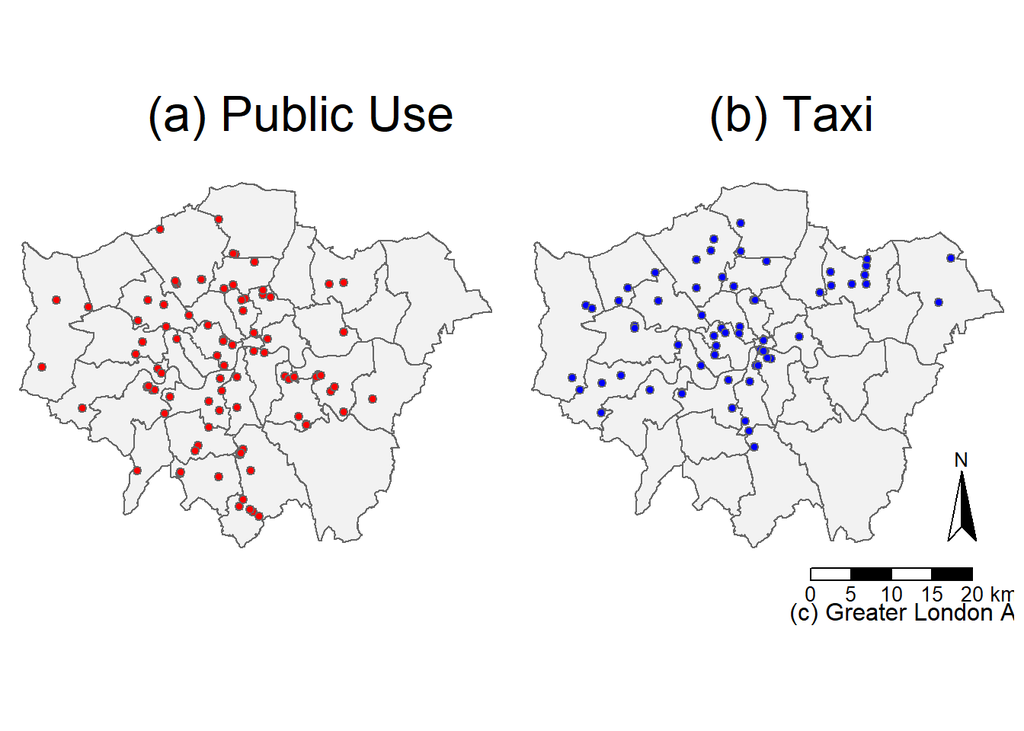

```r
tm1 <- tm_shape(LondonBoroughs)+
  tm_polygons(col="gray",alpha = 0.2)+
  tm_layout(frame=FALSE)+
  tm_shape(public)+
  tm_symbols(col = "red", scale = .4)+
  tm_credits("(a) Public Use", position=c(0.25,0.8), size=2)
tm2 <- tm_shape(LondonBoroughs)+
  tm_polygons(col="gray",alpha = 0.2)+
  tm_layout(frame=FALSE)+
  tm_shape(taxi)+
  tm_symbols(col = "blue", scale = .4)+
  tm_credits("(b) Taxi", position=c(0.35,0.8), size=2)+
  tm_scale_bar(text.size=0.85,position=c(0.57,0.14))+
  tm_compass(north=0,position=c(0.8,0.25),size=3)+
  tm_credits("(c) Greater London Authority",position=c(0.53,0.12),size = 1)
t=tmap_arrange(tm1,tm2)
t
```

Charging point density mapping

1. Public use charging point density in boroughs of London

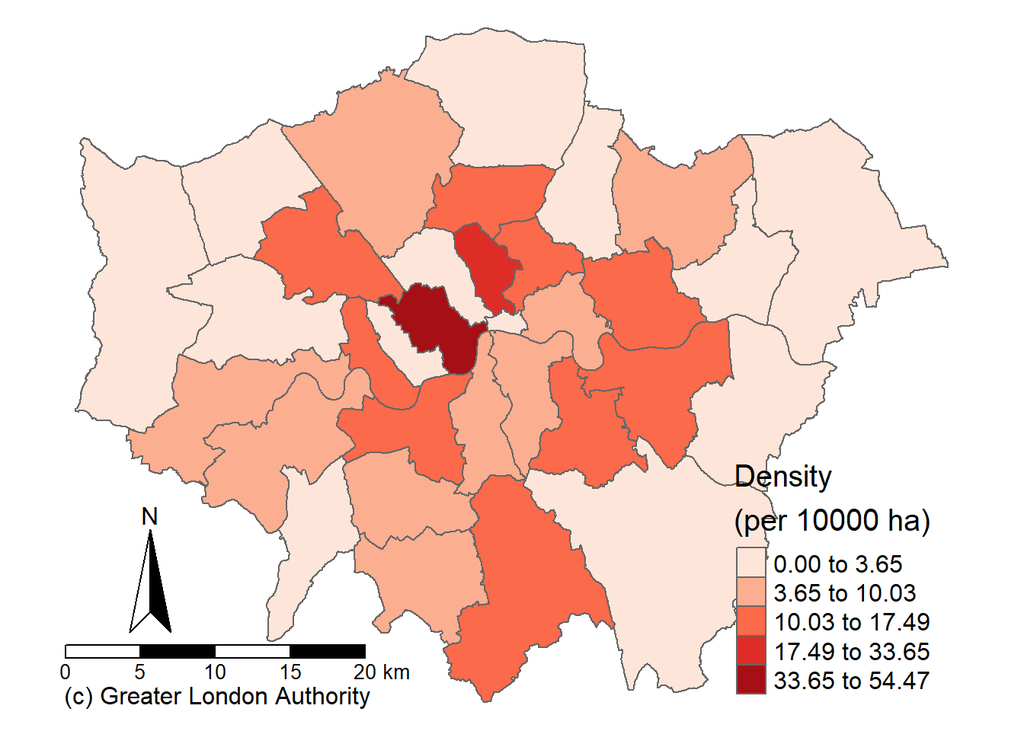

```r
tm3 <- tm_shape(LondonBoroughs) +
  tm_polygons("public_density",
  style="jenks",
  palette=brewer.pal(5, "Reds"),
  midpoint=NA,
  title="Density \n(per 10000 ha)")+
  tm_layout(frame=FALSE,
            legend.position = c("right","bottom"),
            legend.text.size=1,
            legend.title.size = 1.5)+
  tm_scale_bar(text.size=0.85,position=c(0,0.03))+
  tm_compass(north=0,position=c(0.03,0.12),size=3.5,text.size = 1)+
  tm_credits("(c) Greater London Authority",position=c(0,0),size = 1)
tm3
```

2. Taxi charging point density in boroughs of London

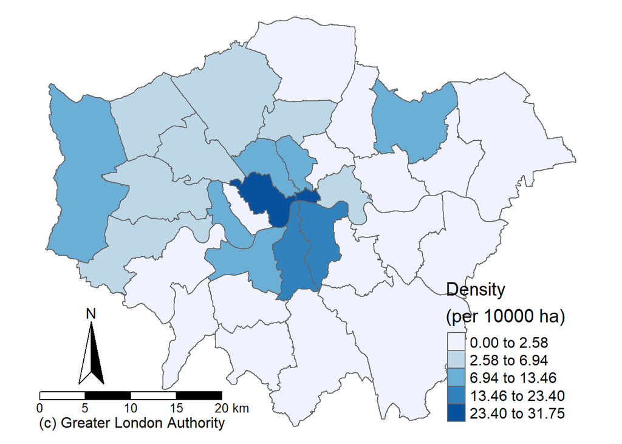

```r
tm4 <- tm_shape(LondonBoroughs) +
  tm_polygons("taxi_density",
              style="jenks",
              palette=brewer.pal(5, "Blues"),
              midpoint=NA,
              title="Density \n(per 10000 ha)")+
  tm_layout(frame=FALSE,
            legend.position = c("right","bottom"),
            legend.text.size=1,
            legend.title.size = 1.5)+
  tm_scale_bar(text.size=0.85,position=c(0,0.03))+
  tm_compass(north=0,position=c(0.03,0.12),size=3.5,text.size = 1)+
  tm_credits("(c) Greater London Authority",position=c(0,0),size = 1)
tm4
```

Plot the histogram of Charging points

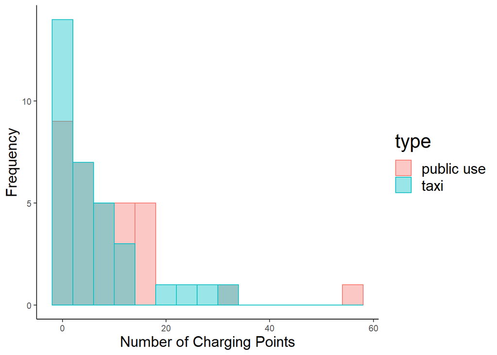

```r
taxi_sub <- LondonBoroughs%>%
  st_drop_geometry()%>%
  select(taxi_density) %>%
  mutate(type="taxi")
names(taxi_sub)[names(taxi_sub) == 'taxi_density'] <- 'density'
public_sub <- LondonBoroughs%>%
  st_drop_geometry()%>%
  select(public_density) %>%
  mutate(type="public use")
names(public_sub)[names(public_sub) == 'public_density'] <- 'density'
sub <-rbind(taxi_sub, public_sub)
gghist <- ggplot(sub, aes(x=density, color=type, fill=type)) +
  geom_histogram(position="identity", alpha=0.4,binwidth =4)+
  labs(x="Number of Charging Points",
       y="Frequency")+
  theme_classic()+
  theme(plot.title = element_text(hjust =0.5),
        legend.title = element_text(size =20),
        legend.text = element_text(size = 15),
        axis.title.x =element_text(size=15),
        axis.title.y=element_text(size=15),)
gghist
```

# Charging site’s Point Pattern Analysis

Do Ripley’s K Tests for both data sets to see if there is any cluster in charging sites

```r
# Set a window as the borough boundary
window <- as.owin(LondonBoroughs)
```

1. Ripley’s K Test on Charging Sites for Public Use in London

```r
public<- public %>%
  as(., 'Spatial')
```

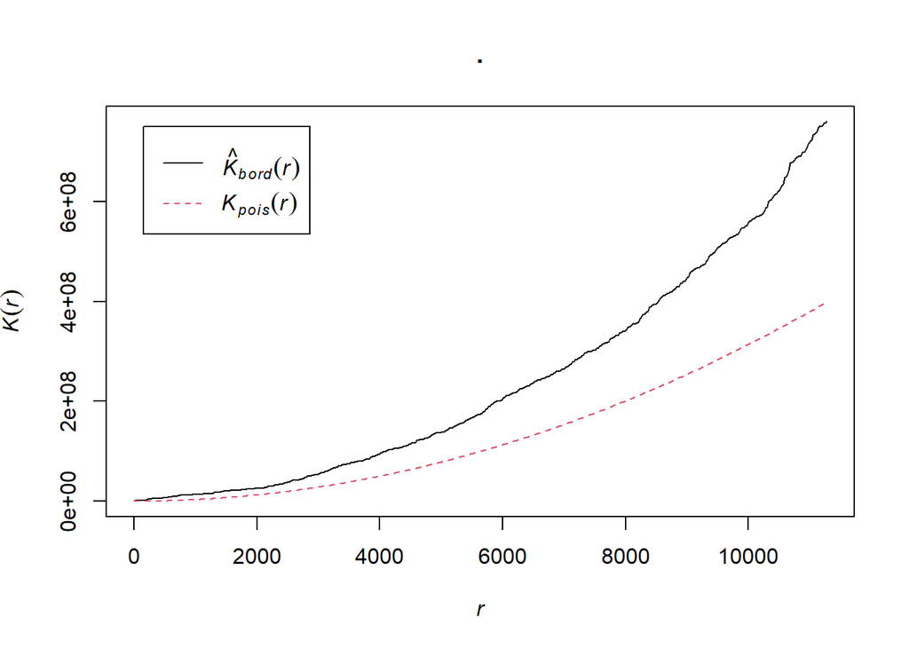

```r
public.ppp <- ppp(x=public@coords[,1],
                          y=public@coords[,2],
                          window=window)
K <- public.ppp %>%
  Kest(., correction="border") %>%
  plot()
```

2. Ripley’s K Test on Charging Sites for Taxi in London

```r
taxi<- taxi %>%
  as(., 'Spatial')
```

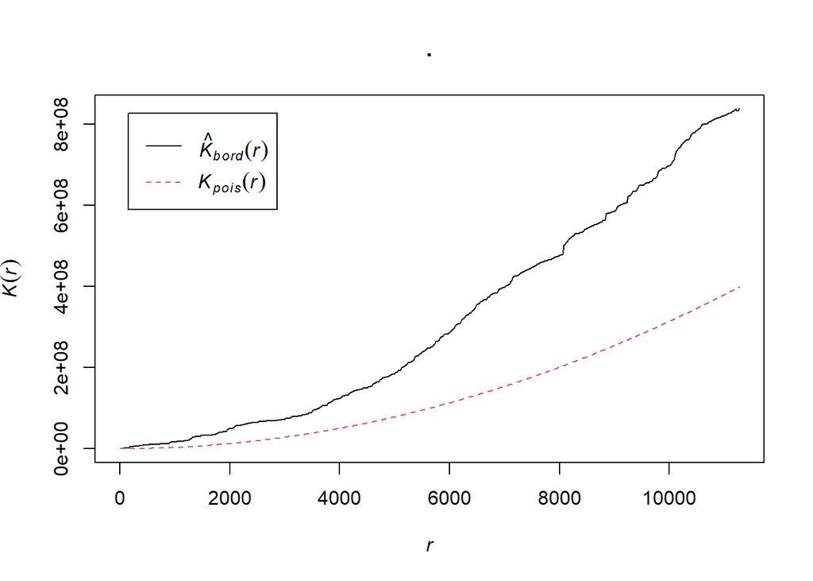

```r
taxi.ppp <- ppp(x=taxi@coords[,1],
                  y=taxi@coords[,2],
                  window=window)
K <- taxi.ppp %>%
  Kest(., correction="border") %>%
  plot()
```

# Global Spatial Autocorrelation analysis

```r
coordsW <- LondonBoroughs %>%
  st_centroid()%>%
  st_geometry()
```

Generate a spatial weights matrix using nearest k-nearest neighbours case

```r
knn_boros <-coordsW %>%
  knearneigh(., k=4) #create a neighbours list of nearest k-nearest neighbours (k=4)
boro_knn <- knn_boros %>%
  knn2nb() %>%
  nb2listw(., style="C")
```

Analysing Spatial Autocorrelation for both charging point density data set

Moran’s I test (tells us whether we have clustered values (close to 1) or dispersed values (close to -1))

1. For taxi points’ density

```r
I_global_taxi <- LondonBoroughs %>%
  pull(taxi_density) %>%
  as.vector()%>%
  moran.test(., boro_knn)
I_global_taxi
```

```
##
##  Moran I test under randomisation
##
## data:  .
## weights: boro_knn
##
## Moran I statistic standard deviate = 3.1165, p-value = 0.0009151
## alternative hypothesis: greater
## sample estimates:
## Moran I statistic       Expectation          Variance
##        0.28744651       -0.03125000        0.01045746
```

2. For public use points’ density

```r
I_global_public <- LondonBoroughs %>%
  pull(public_density) %>%
  as.vector()%>%
  moran.test(., boro_knn)
I_global_public
```

```
##
##  Moran I test under randomisation
##
## data:  .
## weights: boro_knn
##
## Moran I statistic standard deviate = -0.77738, p-value = 0.7815
## alternative hypothesis: greater
## sample estimates:
## Moran I statistic       Expectation          Variance
##       -0.10223076       -0.03125000        0.00833709
```

Geary’s C test (This tells us whether similar values or dissimilar values are cluserting)

1. For taxi points’ density

```r
C_global_taxi <-
  LondonBoroughs %>%
  pull(taxi_density) %>%
  as.vector()%>%
  geary.test(., boro_knn)
C_global_taxi
```

```
##
##  Geary C test under randomisation
##
## data:  .
## weights: boro_knn
##
## Geary C statistic standard deviate = 1.8406, p-value = 0.03284
## alternative hypothesis: Expectation greater than statistic
## sample estimates:
## Geary C statistic       Expectation          Variance
##        0.77622531        1.00000000        0.01478025
```

2. For public use points’ density

```r
C_global_public <-
  LondonBoroughs %>%
  pull(public_density) %>%
  as.vector()%>%
  geary.test(., boro_knn)
C_global_public
```

```
##
##  Geary C test under randomisation
##
## data:  .
## weights: boro_knn
##
## Geary C statistic standard deviate = -0.08548, p-value = 0.5341
## alternative hypothesis: Expectation greater than statistic
## sample estimates:
## Geary C statistic       Expectation          Variance
##        1.01194613        1.00000000        0.01953095
```

Getis Ord G test(This tells us whether high or low values are clustering.)

1. For taxi points’ density

```r
G_global_taxi <-
  LondonBoroughs %>%
  pull(taxi_density) %>%
  as.vector()%>%
  globalG.test(., boro_knn)
G_global_taxi
```

```
##
##  Getis-Ord global G statistic
##
## data:  .
## weights: boro_knn
##
## standard deviate = 3.6095, p-value = 0.0001534
## alternative hypothesis: greater
## sample estimates:
## Global G statistic        Expectation           Variance
##       5.339037e-02       3.125000e-02       3.762439e-05
```

2. For public use points’ density

```r
G_global_public <-
  LondonBoroughs %>%
  pull(public_density) %>%
  as.vector()%>%
  globalG.test(., boro_knn)
G_global_public
```

```
##
##  Getis-Ord global G statistic
##
## data:  .
## weights: boro_knn
##
## standard deviate = -0.37697, p-value = 0.6469
## alternative hypothesis: greater
## sample estimates:
## Global G statistic        Expectation           Variance
##       2.934219e-02       3.125000e-02       2.561304e-05
```

# Local Getis-Ord’s G test

Calculate the Local Getis-Ord’s G z-score for taxi charging point density data

```r
G_local_taxi <- LondonBoroughs %>%
  pull(taxi_density) %>%
  as.vector()%>%
  localG(., boro_knn)
```

Covert into a dataframe and append into borough data frame

```r
G_local_taxi_df <- data.frame(matrix(unlist(G_local_taxi), nrow=33, byrow=T))
LondonBoroughs_test <- LondonBoroughs %>%
  mutate(z_score = as.numeric(G_local_taxi_df$matrix.unlist.G_local_taxi...nrow...33..byrow...T.))
```

Plot a map of the local Getis-Ord’s G z-score

```r
# Set the breaks and color bar manually
breaks1<-c(-3.00,-2.58,-1.96,-1.65,1.65,1.96,2.58,3.00)
MoranColours<- rev(brewer.pal(8, "RdBu"))
# Plot the local Getis-Ord’s G test z-score map
tmap_mode("plot")
```

```
## tmap mode set to plotting
```

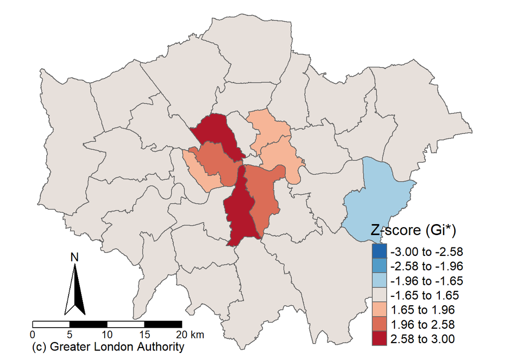

```r
zscore_taxi <- tm_shape(LondonBoroughs_test) +
  tm_polygons("z_score",
              style="fixed",
              breaks=breaks1,
              palette=MoranColours,
              midpoint=NA,
              title="Z-score (Gi*)")+
  tm_layout(frame=FALSE,
            legend.position = c("right","bottom"),
            legend.text.size=1,
            legend.title.size = 1.5)+
  tm_scale_bar(text.size=0.85,position=c(0,0.03))+
  tm_compass(north=0,position=c(0.03,0.12),size=3.5,text.size = 1)+
  tm_credits("(c) Greater London Authority",position=c(0,0),size = 1)
zscore_taxi
```